# Lynx

[NO_LYNX_001]

Authors

Affiliations

Aud H. Halbritter

University of Bergen

Erik Framstad

Norwegian Institute for Nature Research

Katrine Eldegard

Norwegian University of Life Sciences

Published

May 15, 2026

Reviewed by

Matthew Grainger

> **Recommended citation**: Halbritter, A. H., Framstad, E., Eldegard, K. 2026. Lynx abundance (ID(s): NO_LYNX_001) v. 1.0.0. ecRxiv: https://github.com/NINAnor/ecRxiv/tree/main/indicators/NO_LYNX_001

**TipMetadata**

Table 1: Indicator metadata

| Variable | Value |
| --- | --- |
| Indicator ID | NO_LYNX_001 |
| Indicator Name | Lynx abundance |
| verbatimName | Gaupebestand |
| Country | Norway |
| Continent | Europe |
| Ecosystem Condition Typology Class | B3 Functional state characteristics |
| Realm | Terrestrial (T) |
| Biome | T2 Temperate-boreal forests and woodlands biome |
| Ecosystem | T2.1 Boreal/montane forests |
| verbatimEcosystem | boreal/subalpin skog |
| Year added | 2026 |
| Last update | 2026 |
| Version | 1.0.0 |
| Version comment | First version on ecRxiv; indicator described in the Norwegian Nature Index |
| Normalised | TRUE |
| Spatial aggregation pathway | Aggregate (population model, large-carnivore management region) - [Scale - Truncate] - Downscale (municipalities) - Aggregate (geographic region) - Aggregate (national level) |
| Precision | Approximate 95% Monte Carlo interval (2.5th–97.5th percentile of 1000 resampled area-weighted means) as inferential uncertainty around the point estimate (median). |

**TipLog**

- May 15, 2026 - Initial draft for ecRxiv
- July 17, 2026 - Accepted

## 1. Summary

1. **Background and rationale**: The Eurasian lynx (*Lynx lynx*) is the largest feline species in the European landscape and the only native wild cat in Norway. As a “small big cat,” it occupies a unique trophic niche, primarily hunting small ungulates such as roe deer through a characteristic stalking and ambush tactic (Breitenmoser and Breitenmoser-Würsten 2026). In Norway, it lives mainly in forest areas over large parts of the country, and the densest populations are in Mid-Norway and eastern Norway. Lynx population dynamics are often influenced by the availability of staple prey and anthropogenic pressures, including habitat fragmentation and human-induced mortality.

The indicator is part of the Norwegian Nature Index and is described on [Naturindeksen](https://naturindeks.no/Indicators/gaupe).

## 1.2 Native language summary - Norwegian

1. **Bakgrunn og begrunnelse**: Gaupe (*Lynx lynx*) er den største kattedyrarten i Europa og det eneste stedegne ville kattedyret i Norge. Som en «liten stor katt» inntar den en unik plass i næringskjeden, og den jakter primært på rådyr ved hjelp av en karakteristisk «snikjakt» (Breitenmoser and Breitenmoser-Würsten 2026). I Norge lever gaupa hovedsakelig i skogsområder over store deler av landet, og de tetteste bestandene finnes i Midt-Norge og Øst-Norge. Gaupebestandens størrelse og utvikling påvirkes ofte av tilgangen på byttedyr og menneskelig påvirkning, blant annet fragmentering av leveområder og menneskeskapt dødelighet. Indikatoren inngår i Naturindeksen og er beskrevet på [Naturindeksen](https://naturindeks.no/Indicators/gaupe).
2. **Metoder**: Indikatorverdier for gaupebestand hentes fra Naturindeks-databasen (via `NIcalc`-API i denne arbeidsflyten). Bestandsovervåking og statusrapportering for gaupe koordineres av [Rovdata](https://rovdata.no/Gaupe.aspx). Status for 2025 oppgis blant annet som et intervall for antall gauper, knyttet til antall familiegrupper (Rovdata 2025).
3. **Tolkning**: En indikatorverdi på 1 betyr at gaupebestanden i rapporteringsenheten er minst like stor som forventet under referansetilstanden i Naturindeksen. Verdier som nærmer seg null, viser at bestandsindekset ligger lenger under referansen.
4. **Resultater og utviklingsbehov**: Indikatoren brukes i Naturindeksen.

## 2. About the underlying data

For Naturindeks reporting, prepared indicator objects are obtained from the Naturindeks database. Lynx population monitoring in Norway is described and reported by [Rovdata](https://rovdata.no/Gaupe.aspx), under the national monitoring programme for large carnivores.

### 2.1 Spatial and temporal resolution and extent

Indicator values are available for the assessment years in Naturindeksen: 2000, 2010, 2014, 2019, and 2024.

To produce indicator estimates for these years, input is combined over a short window (typically two to three years), as specified in the Naturindeks indicator protocol.

Spatially, data are organised by the eight large-carnivore management regions (*forvaltningsregioner for rovvilt*, regions 1–8). Rovdata publishes status by these regions, including national targets for annual family groups of lynx per region (Rovdata 2025). In Naturindeksen, indicator and reference values are stored at management-region scale (IC units), then aggregated to five geographic regions and national level for reporting.

### 2.2 Sampling design

[Rovdata](https://rovdata.no/Gaupe.aspx) is responsible for monitoring lynx in Norway and for maintaining an overview of how many lynx there are in the country. The status pages report population status using family groups of lynx and national/regional targets set by the Storting (Rovdata 2025).

### 2.3 Original units

The unit of the raw data is the number of family groups of lynx.

### 2.4 Instructions for citing, using and accessing data

Population monitoring and status information are accessible at [Rovdata](https://rovdata.no/Gaupe.aspx) and the relevant status pages (Rovdata 2025). Methodological documentation for the indicator: [Naturindeksen – gaupe](https://naturindeks.no/Indicators/gaupe).

## 3. Indicator properties

### 3.1 Ecosystem Condition Typology Class (ECT)

Large carnivores function as apex predators, regulating prey populations and potentially exerting cascading effects on vegetation composition and the recruitment of tree species. Hence, this indicator is considered to fall under B3 - Functional state characteristics.

### 3.2 Ecosystem condition characteristic

### 3.3 Collinearities with other indicators

The indicator for lynx may covary with other large-carnivore indicators (wolf, brown bear, wolverine) where distributions overlap. In a natural system this would primarily reflect shared prey availability. In contemporary Norway, however, population levels of all large carnivores are primarily determined by management rather than ecological dynamics.

### 3.4 Impact factors

Natural regulation of Norway’s Eurasian lynx population is primarily driven by prey availability, particularly roe deer, alongside intraspecific social mechanisms such as territoriality. However, these natural constraints are often superseded by anthropogenic factors, specifically a management policy that classifies the lynx as a game species subject to legal hunting quotas (licence hunting) to mitigate conflicts over high levels of livestock depredation. Furthermore, the overall population size is influenced by illegal killing.

### 3.5 Spatial aggregation

Following the metadata pathway Aggregate (population model, large-carnivore management region) – [Scale – Truncate] – Downscale (municipalities) – Aggregate (geographic region) – Aggregate (national level): population estimates or indices are available per forvaltningsregion for rovvilt (IC unit in Naturindeksen). Each unit is normalised against *X<sub>0</sub>* and *X<sub>100</sub>* for that region (linear scaling with truncation to [0, 1]).

Because rovvilt regions and the five Naturindeks geographic regions are two non-aligned partitions of Norway, we use municipalities (`BSunits`) as a common basic spatial unit. We assign the (scaled) rovvilt-region value to each municipality belonging to that region (uniform-value assumption), hereafter referred to as downscaling. Forest area (`Skog`) is used as the aggregation weight because lynx is a forest-associated species.

## 4. Reference condition and levels

### 4.1 Reference condition

The reference condition for the Eurasian lynx represents the natural population state that occurs in the absence of significant human influence. In this state, population dynamics and size are regulated by natural processes – primarily prey availability. The lynx fulfils a vital functional role in Norwegian forest ecosystems as a specialised predator of roe deer, but it is a highly adaptable hunter that incorporates hares as a significant secondary prey source. By exerting top-down control, the lynx influences not only prey numbers but also their behaviour, distribution, and vigilance.

### 4.2 Reference levels

*X<sub>100</sub>* is set per large-carnivore management region (IC unit in Naturindeksen), using suitable area and density within each *rovviltregion* and expert assessment: it represents the expected lynx population (or equivalent index) under reference conditions in that unit.

*X<sub>0</sub>* is defined as no lynx in the unit (functional absence).

#### 4.2.1 Spatial resolution and validity

Reference levels and indicator values apply at the scale of forvaltningsregioner for rovvilt (IC units). Aggregated results for the five Naturindeks geographic regions and for Norway are summaries of those units with area weights.

## 5. Uncertainties

### 5.1 General uncertainties

Reference levels are held fixed in this workflow (their own uncertainties are not propagated). Regional and national values are area-weighted summaries of forvaltningsregioner for rovvilt, so they inherit model uncertainty at management-region scale and any mismatch between administrative regions and ecological variation within the five Naturindeks geographic regions. Monitoring design and sample effort differ between species and regions; uneven coverage can affect the population models that enter Naturindeksen.

### 5.2 Reported uncertainties

For each management region and assessment year, Naturindeks provides a predictive distribution for the population index (on the variable scale before scaling). We draw `nsim = 1000` values per region, scale each draw to the 0–1 indicator scale using the regional reference level and linear scaling, then downscale by assigning each scaled draw to every municipality in that region and aggregate with `ecTools::ec_upscale()`: first from municipalities (`BSunits`) to each NI geographic region (`part`), then from regions to Norway, using forest area (`Skog`) as the weight. The 1000 `sampled_mean` values per region and year describe inferential uncertainty for the forest-area-weighted mean indicator; we summarise them with the median and 2.5% and 97.5% quantiles as an approximate 95% interval, and the 25% and 75% quantiles as an approximate interquartile range.

## 6. References

Breitenmoser, U., and C. Breitenmoser-Würsten. 2026. “Eurasian Lynx *Lynx Lynx* (Linnaeus, 1758).” In *Carnivora. Handbook of the Mammals of Europe*, edited by Anna Loy and Paolo Ciucci. Springer. https://doi.org/10.1007/978-3-030-44035-0_123.

Norwegian Institute for Nature Research, and partners. 2025. *Norwegian Nature Index (Naturindeks)*. https://www.naturindeks.no.

Rovdata. 2025. *Bestandsstatus: Gaupe*. https://rovdata.no/Gaupe/Bestandsstatus.aspx.

## 7. Import and prepare datasets

Run the download chunk once to refresh the local export. This project’s renv environment installs `NIcalc` from GitHub `ChloeRN/NIcalc`, branch `include_ReadOnly_access` (see `renv.lock` and `install_deps.R`); that build defaults to the Naturindeks read-only API user, so you do not need `username` / `password` arguments here. When [NINAnor/NIcalc PR #59](https://github.com/NINAnor/NIcalc/pull/59) is merged into `NINAnor/NIcalc`, you can switch the renv install back to the main repo and update the lockfile. We save the RDS export under `data/` so that we do not need to download the data every time we run the analysis.

**Download lynx data from Naturindeks API**

```r
lynxImport <- NIcalc::importDatasetApi(
  eco = NULL,
  indic = c("Gaupe"),
  year = c("2000", "2010", "2014", "2019", "2024")
)

saveRDS(lynxImport, here::here("data/lynxImport.rds"))
```

## 8. Spatial units

According to Naturindeks terminology, municipalities are `BSunits`. The eight forvaltningsregioner for rovvilt (rovvilt regions 1–8) are subsamples of `BSunits` and are referred to as `ICunits` in the import; they are the IC units for this indicator. The five Naturindeks geographic regions (east, south, west, central, north; codes E, S, W, C, N) are `parts` and `NIunits`, taken from the `part` field on municipality-level `BSunits` in the same import (see Section 9 for downscaling and aggregation). Mainland Norway is the ecosystem accounting area.

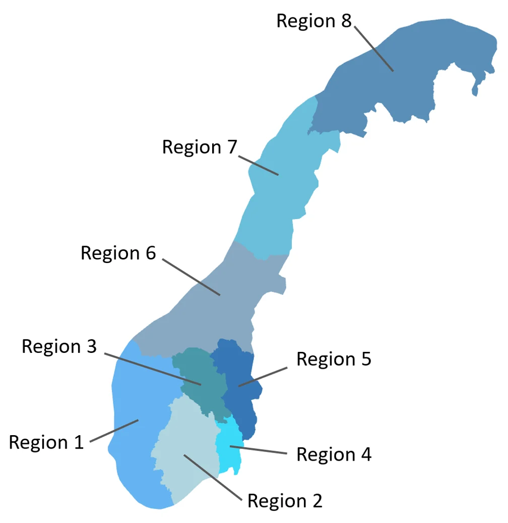

Figure 1: Map of the eight carnivore management regions (rovvilt regions) in Norway.

```r
knitr::include_graphics(here::here("img/rovviltregioner.png"))
```

## 9. Analyses

This section uses the following workflow: we take variable values and reference levels from the Naturindeks import, normalise at large-carnivore management-region scale (IC unit) with linear scaling, then downscale by assigning the scaled values to the municipalities in each region and propagate uncertainty and aggregate spatially with forest-area weights using `ecTools::ec_upscale()`. At geographic (NI part) and national scale, uncertainties are inferential: each replicate is a forest-area-weighted mean across municipalities (then, for Norway, one draw per NI region). We use linear scaling and forest area (`Skog`) from the Naturindeks spatial framework as the weight.

Management-region population indices in the database are stored as predictive distributions, not only as point estimates. Reference levels per region (*X<sub>0</sub>* = 0, *X<sub>100</sub>* from the download) are applied before any geographic or national aggregation. We ignore uncertainty in the reference levels themselves.

### Assemble import and indicator object

`assembleNiObject()` reshapes `lynxImport` so that indicator observations are in one list element per assessment year, and so that underlying spatial units (`BSunits`) are aligned with the thematic index structure used in Naturindeks.

**Assemble lynx NI object (thematic, predefined regions)**

```r
lynxAssemble <- NIcalc::assembleNiObject(
  inputData = lynxImport,
  predefNIunits = c(allArea = T, parts = T, counties = F),
  indexType = "thematic"
)
```

### Reference levels (X<sub>0</sub> and X<sub>100</sub>)

Before scaling, we read regional reference levels from `referenceValues` in the RDS export (rows with `yearId == 0` or reference year name). For this indicator, *X<sub>0</sub>* is zero individuals in the unit and *X<sub>100</sub>* is the expert reference population index per rovvilt region (`expectedValue` in the reference slice).

**Management-region reference levels from downloaded Naturindeks data**

```r
refs <- lynxImport$referenceValues$referenceValues |>
  dplyr::filter(.data$yearId == 0L | grepl("Referanse", .data$yearName, fixed = FALSE)) |>
  dplyr::distinct(ICunitId, ICunitName, x100 = expectedValue) |>
  dplyr::mutate(x0 = 0)
refs |>
  gt::gt()
```

Management-region reference levels (X0 = 0, X100) by rovvilt region (IC unit).

| ICunitId | ICunitName | x100 | x0 |
| --- | --- | --- | --- |
| 3812 | Rovviltregion 8 | 143 | 0 |
| 3815 | Rovviltregion 7 | 71 | 0 |
| 3816 | Rovviltregion 6 | 110 | 0 |
| 3819 | Rovviltregion 3 | 47 | 0 |
| 3820 | Rovviltregion 5 | 54 | 0 |
| 3822 | Rovviltregion 4 | 18 | 0 |
| 3825 | Rovviltregion 2 | 82 | 0 |
| 5140 | Rovviltregion 1 | 80 | 0 |

### Resample non-scaled management-region variables

For each assessment year, Naturindeks stores one value per rovvilt region as a parameterised distribution (or a custom distribution). We draw `nsim = 1000` random values per region with `NIcalc::sampleObsMat()`. Rows with a standard distribution family use observation type `tradObs`; rows with only a custom distribution use `customObs`.

Assessment years are 2000, 2010, 2014, 2019, and 2024. The result `mgmt_draws` is a long table of simulated population indices (`value`) by `ICunitId` and `year`, not yet on the 0–1 indicator scale.

**Observation types for sampleObsMat**

```r
myYears <- as.character(c(2000, 2010, 2014, 2019, 2024))
obstype <- vector("list", length(myYears))
for (i in seq_along(myYears)) {
  obs <- lynxAssemble$indicatorValues[[i]]$distributionFamilyName
  obs[!is.na(obs)] <- "tradObs"
  obs[is.na(obs)] <- "customObs"
  obstype[[i]] <- obs
}
```

**Resample management-region variables (non-scaled)**

```r
mgmt_draws <- tibble(ICunitId = NULL, value = NULL, year = NULL)

for (i in seq_along(myYears)) {
  myMat <- NIcalc::sampleObsMat(
    ICunitId = lynxAssemble$indicatorValues[[i]]$ICunitId,
    value = lynxAssemble$indicatorValues[[i]]$expectedValue,
    distrib = lynxAssemble$indicatorValues[[i]]$distributionFamilyName,
    mu = lynxAssemble$indicatorValues[[i]]$distParameter1,
    sig = lynxAssemble$indicatorValues[[i]]$distParameter2,
    customDistribution = lynxAssemble$indicatorValues[[i]]$customDistribution,
    obsType = obstype[[i]],
    nsim = 1000
  )
  ICunitIds <- row.names(myMat)
  colnames(myMat) <- paste0("s", seq_len(ncol(myMat)))
  myMat <- myMat |>
    as_tibble() |>
    add_column(ICunitId = ICunitIds, .before = 1) |>
    pivot_longer(cols = -any_of("ICunitId"), names_to = "sim_col", values_to = "value") |>
    mutate(
      sim_id = readr::parse_number(.data$sim_col),
      year = myYears[i]
    ) |>
    select(ICunitId, sim_id, value, year)

  mgmt_draws <- mgmt_draws |>
    bind_rows(myMat)
}
head(mgmt_draws) |>
  gt::gt()
```

Preview of resampled management-region variable values (first rows).

| ICunitId | sim_id | value | year |
| --- | --- | --- | --- |
| 3812 | 1 | 3.712194 | 2000 |
| 3812 | 2 | 4.676109 | 2000 |
| 3812 | 3 | 5.459659 | 2000 |
| 3812 | 4 | 7.784095 | 2000 |
| 3812 | 5 | 1.580642 | 2000 |
| 3812 | 6 | 6.749750 | 2000 |

### Scaling to indicator values (linear)

Normalisation is done at management-region scale before any geographic or national aggregation. Each draw is joined to its regional `x0` and `x100`, then mapped to `[0, 1]` with `ecTools::ec_normalise()` using linear increasing scaling from *X<sub>0</sub>* to *X<sub>100</sub>* (no upper-tail unimodal anchor).

**Join reference levels and linear scaling to indicator scale**

```r
mgmt_draws <- mgmt_draws |>
  left_join(
    refs |> mutate(ICunitId = as.character(ICunitId)),
    by = join_by(ICunitId)
  )

ind <- ec_normalise(
  variable = mgmt_draws$value,
  x0 = mgmt_draws$x0,
  x100 = mgmt_draws$x100,
  fun = "linear"
)

mgmt_draws <- mgmt_draws |> add_column(indicator = ind)
```

The scatter plot below (Figure 2) shows the mapping from variable to indicator for each rovvilt region (one facet per `ICunitName`). The figure is saved when the document is rendered.

**Save normalisation diagnostic figure**

```r
lynx_norm_plot <- ec_norm_plot(mgmt_draws$value, mgmt_draws$indicator) +
  facet_wrap(. ~ mgmt_draws$ICunitName) +
  ggplot2::theme(axis.text = ggplot2::element_text(size = 9))
lynx_norm_plot$layers[[1]]$aes_params$size <- 3

suppressMessages(
  ggsave(
    filename = here::here("img/lynx_norm_plot.png"),
    plot = lynx_norm_plot,
    scale = 1.5
  )
)
```

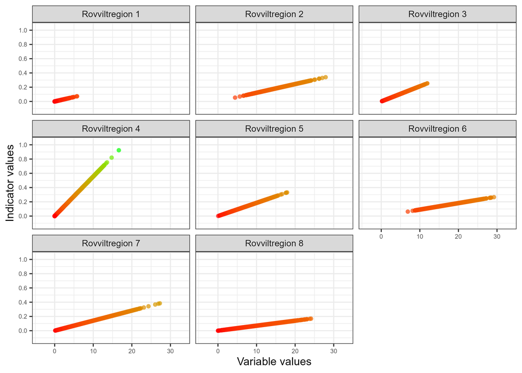

Figure 2: Linear normalisation of lynx population index to indicator values (one panel per management region).

```r
knitr::include_graphics(here::here("img/lynx_norm_plot.png"))
```

### Aggregation weights (forest area by municipality)

Spatial aggregation uses forest area (`Skog`) on each underlying municipality in `BSunits`. Municipalities are linked to rovvilt regions via `ICunits`, and each `BSunit` carries a Naturindeks geographic region code (`part`: E, S, W, C, N). Rovvilt regions and NI parts are two non-aligned partitions of Norway, so we keep the data at municipality level once it is scaled: each municipality inherits the scaled indicator value of its rovvilt region (uniform-value assumption), and is then aggregated upward with its own forest area.

**Forest area, NI part, and IC link per municipality**

```r
mgmt_weights <- as_tibble(lynxAssemble$BSunits) |>
  rename(BSunitId = id)

IC_BC_link <- lynxImport$ICunits |>
  distinct(ICunitId = as.character(id), BSunitId)

mgmt_weights <- mgmt_weights |>
  left_join(IC_BC_link, by = join_by(BSunitId)) |>
  mutate(ICunitId = as.character(ICunitId))
```

Downscale the scaled indicator values from each rovvilt region by assigning them to every municipality in that region. The result is a long table with one row per (`year`, `sim_id`, `BSunitId`) carrying its rovvilt region’s indicator draw, its `part`, and the municipality’s `Skog`.

**Downscale rovvilt-region draws to municipalities**

```r
mgmt_draws <- mgmt_draws |>
  mutate(ICunitId = as.character(ICunitId))

bsunit_draws <- mgmt_draws |>
  right_join(
    mgmt_weights |> select(BSunitId, ICunitId, part, Skog),
    by = join_by(ICunitId),
    unmatched = "error",
    relationship = "many-to-many"
  )
```

### Spatial aggregation

Aggregate from municipalities to NI geographic regions with `ecTools::ec_upscale()`, using Monte Carlo propagation of inferential uncertainty (one draw per municipality per replicate, forest-area-weighted mean).

**Municipality to NI part MC propagation (ec_upscale)**

```r
mc_propagated <- ecTools::ec_upscale(
  data = bsunit_draws,
  variable = indicator,
  weight = Skog,
  start_units = BSunitId,
  end_units = part,
  year = year,
  end_units_name = "part",
  n = 1000
)
saveRDS(mc_propagated, here::here("data/lynx_mc_propagated_regional.rds"))
```

For the national indicator, propagate again from regions to Norway. Summed forest area per geographic region is used as the weight at this step.

**Total forest area per NI region**

```r
region_weights <- mgmt_weights |>
  group_by(part) |>
  summarise(forest_area = sum(.data$Skog, na.rm = TRUE), .groups = "drop")
region_weights
```

```
# A tibble: 5 × 2
  part  forest_area
  <chr>       <dbl>
1 C          20568.
2 E          39436.
3 N          30469.
4 S          18229.
5 W          11479.
```

**NI region to Norway MC propagation (ec_upscale)**

```r
mc_propagated_for_national <- mc_propagated |>
  left_join(region_weights, by = join_by(part)) |>
  add_column(end_units = "Norway")

mc_propagated_national <- ecTools::ec_upscale(
  data = mc_propagated_for_national,
  variable = sampled_mean,
  weight = forest_area,
  start_units = part,
  end_units = end_units,
  year = year,
  end_units_name = "part",
  n = 1000
)
saveRDS(mc_propagated_national, here::here("data/lynx_mc_propagated_national.rds"))
```

Regional and national MC draws are combined for summarisation and export.

**Bind regional and national MC outputs**

```r
mc_propagated_combined <- mc_propagated |>
  select(year, part, sampled_mean) |>
  bind_rows(mc_propagated_national)
```

## 10. Results

From the 1000 Monte Carlo replicates per region and year in `mc_propagated_combined`, we report the median as the point estimate and use the 2.5% and 97.5% quantiles as an approximate 95% interval for the forest-area-weighted mean indicator (inferential uncertainty, not descriptive spread between management regions). The tables (Table 2, Table 3) and time series (Figure 3) summarise regional and national (`Norway`) values separately.

```r
summary_out <- mc_propagated_combined |>
  mutate(part = dplyr::recode(part, !!!lynx_part_labels)) |>
  group_by(part, year) |>
  summarise(
    median = round(median(sampled_mean), 2),
    p_025 = round(quantile(sampled_mean, probs = 0.025), 2),
    p_25 = round(quantile(sampled_mean, probs = 0.25), 2),
    p_75 = round(quantile(sampled_mean, probs = 0.75), 2),
    p_975 = round(quantile(sampled_mean, probs = 0.975), 2),
    .groups = "drop"
  ) |>
  mutate(part = factor(part, levels = lynx_region_levels)) |>
  add_column(
    ECT = "B3",
    Indicator = "Lynx abundance",
    Ecosystem = "Boreal/montane forests",
    ID = "NO_LYNX_001"
  )
```

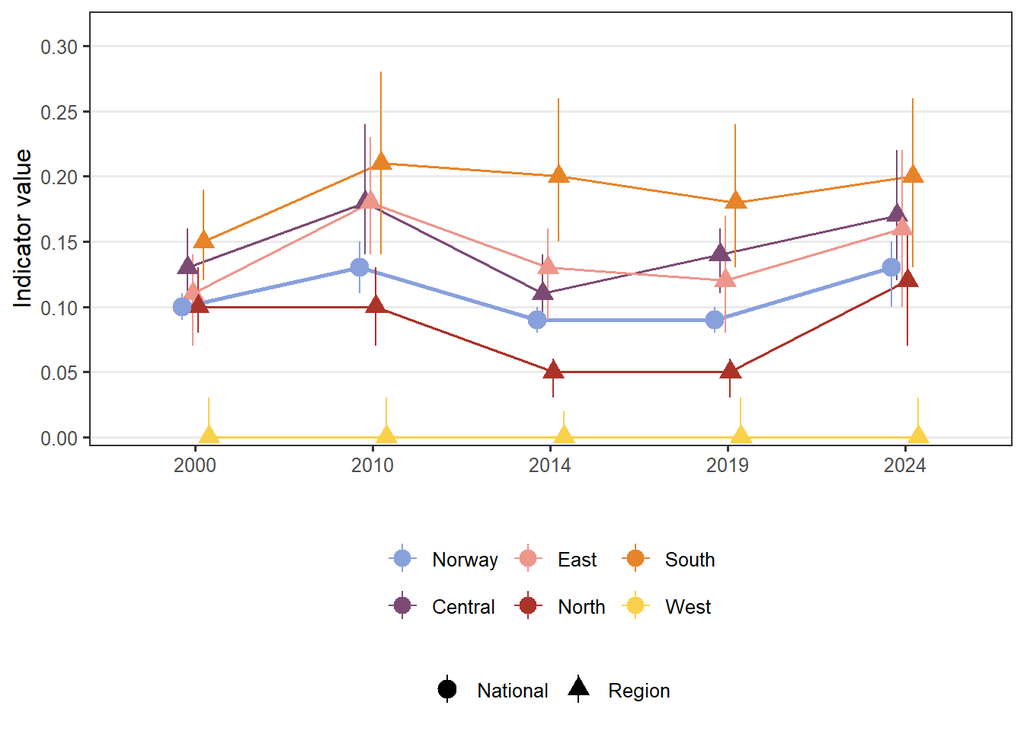

Figure 3: Indicator values for lynx abundance by region and nationally, with uncertainty bands from the resampled distribution.

```r
lynx_plot_years <- as.character(c(2000, 2010, 2014, 2019, 2024))
lynx_region_cols <- setNames(
  MetBrewer::met.brewer("Archambault", n = length(lynx_region_levels)),
  lynx_region_levels
)

plot_data <- summary_out |>
  mutate(
    year = factor(year, levels = lynx_plot_years),
    series_type = if_else(part == "Norway", "National", "Region")
  )

y_hi <- max(plot_data$p_975, na.rm = TRUE)
y_max <- min(1, max(0.08, y_hi * 1.12, na.rm = TRUE))
y_breaks <- pretty(c(0, y_max), n = 6)

ggplot(plot_data, aes(x = year, y = median, colour = part, group = part)) +
  geom_line(
    aes(linewidth = series_type),
    position = position_dodge(width = 0.18)
  ) +
  geom_pointrange(
    aes(ymin = p_025, ymax = p_975, shape = series_type),
    size = 0.8,
    linewidth = 0.45,
    position = position_dodge(width = 0.18)
  ) +
  scale_colour_manual(values = lynx_region_cols, name = NULL) +
  scale_shape_manual(
    values = c(National = 19, Region = 17),
    name = NULL
  ) +
  scale_linewidth_manual(
    values = c(National = 1, Region = 0.55),
    guide = "none"
  ) +
  scale_y_continuous(
    limits = c(0, y_max),
    breaks = y_breaks,
    expand = ggplot2::expansion(mult = c(0.02, 0.04))
  ) +
  theme_bw(base_size = 12) +
  theme(
    legend.position = "bottom",
    legend.box = "vertical",
    panel.grid.minor = element_blank(),
    panel.grid.major.x = element_blank()
  ) +
  guides(
    colour = guide_legend(nrow = 2, override.aes = list(size = 0.7, linewidth = 0.45)),
    shape = guide_legend(override.aes = list(size = 0.8, linewidth = 0.45))
  ) +
  labs(y = "Indicator value", x = "")
```

```r
summary_out |>
  filter(part != "Norway") |>
  arrange(part, year) |>
  unite(col = "CI_95", c(p_025, p_975), sep = " - ") |>
  unite(col = "IQR", c(p_25, p_75), sep = " - ") |>
  select(
    ECT,
    Indicator,
    ID,
    "Accounting area" = part,
    Ecosystem,
    "Closing year" = year,
    "Indicator value" = median,
    "95% CI" = CI_95,
    "50% CI" = IQR
  ) |>
  kable()
```

Table 2: Indicator values and uncertainty estimates for lynx abundance by geographic region.

| ECT | Indicator | ID | Accounting area | Ecosystem | Closing year | Indicator value | 95% CI | 50% CI |
| --- | --- | --- | --- | --- | --- | --- | --- | --- |
| B3 | Lynx abundance | NO_LYNX_001 | Central | Boreal/montane forests | 2000 | 0.13 | 0.11 - 0.16 | 0.12 - 0.14 |
| B3 | Lynx abundance | NO_LYNX_001 | Central | Boreal/montane forests | 2010 | 0.18 | 0.14 - 0.24 | 0.17 - 0.2 |
| B3 | Lynx abundance | NO_LYNX_001 | Central | Boreal/montane forests | 2014 | 0.11 | 0.09 - 0.14 | 0.1 - 0.12 |
| B3 | Lynx abundance | NO_LYNX_001 | Central | Boreal/montane forests | 2019 | 0.14 | 0.11 - 0.16 | 0.13 - 0.15 |
| B3 | Lynx abundance | NO_LYNX_001 | Central | Boreal/montane forests | 2024 | 0.17 | 0.12 - 0.22 | 0.15 - 0.19 |
| B3 | Lynx abundance | NO_LYNX_001 | East | Boreal/montane forests | 2000 | 0.11 | 0.07 - 0.14 | 0.09 - 0.12 |
| B3 | Lynx abundance | NO_LYNX_001 | East | Boreal/montane forests | 2010 | 0.18 | 0.14 - 0.23 | 0.17 - 0.2 |
| B3 | Lynx abundance | NO_LYNX_001 | East | Boreal/montane forests | 2014 | 0.13 | 0.09 - 0.16 | 0.12 - 0.14 |
| B3 | Lynx abundance | NO_LYNX_001 | East | Boreal/montane forests | 2019 | 0.12 | 0.08 - 0.17 | 0.11 - 0.13 |
| B3 | Lynx abundance | NO_LYNX_001 | East | Boreal/montane forests | 2024 | 0.16 | 0.1 - 0.22 | 0.14 - 0.18 |
| B3 | Lynx abundance | NO_LYNX_001 | North | Boreal/montane forests | 2000 | 0.10 | 0.08 - 0.13 | 0.09 - 0.11 |
| B3 | Lynx abundance | NO_LYNX_001 | North | Boreal/montane forests | 2010 | 0.10 | 0.07 - 0.13 | 0.09 - 0.11 |
| B3 | Lynx abundance | NO_LYNX_001 | North | Boreal/montane forests | 2014 | 0.05 | 0.03 - 0.06 | 0.04 - 0.05 |
| B3 | Lynx abundance | NO_LYNX_001 | North | Boreal/montane forests | 2019 | 0.05 | 0.03 - 0.06 | 0.04 - 0.05 |
| B3 | Lynx abundance | NO_LYNX_001 | North | Boreal/montane forests | 2024 | 0.12 | 0.07 - 0.16 | 0.1 - 0.13 |
| B3 | Lynx abundance | NO_LYNX_001 | South | Boreal/montane forests | 2000 | 0.15 | 0.12 - 0.19 | 0.14 - 0.16 |
| B3 | Lynx abundance | NO_LYNX_001 | South | Boreal/montane forests | 2010 | 0.21 | 0.14 - 0.28 | 0.18 - 0.23 |
| B3 | Lynx abundance | NO_LYNX_001 | South | Boreal/montane forests | 2014 | 0.20 | 0.15 - 0.26 | 0.18 - 0.22 |
| B3 | Lynx abundance | NO_LYNX_001 | South | Boreal/montane forests | 2019 | 0.18 | 0.13 - 0.24 | 0.17 - 0.2 |
| B3 | Lynx abundance | NO_LYNX_001 | South | Boreal/montane forests | 2024 | 0.20 | 0.13 - 0.26 | 0.17 - 0.22 |
| B3 | Lynx abundance | NO_LYNX_001 | West | Boreal/montane forests | 2000 | 0.00 | 0 - 0.03 | 0 - 0.01 |
| B3 | Lynx abundance | NO_LYNX_001 | West | Boreal/montane forests | 2010 | 0.00 | 0 - 0.03 | 0 - 0.01 |
| B3 | Lynx abundance | NO_LYNX_001 | West | Boreal/montane forests | 2014 | 0.00 | 0 - 0.02 | 0 - 0.01 |
| B3 | Lynx abundance | NO_LYNX_001 | West | Boreal/montane forests | 2019 | 0.00 | 0 - 0.03 | 0 - 0.01 |
| B3 | Lynx abundance | NO_LYNX_001 | West | Boreal/montane forests | 2024 | 0.00 | 0 - 0.03 | 0 - 0.01 |

```r
summary_out |>
  filter(part == "Norway") |>
  arrange(year) |>
  unite(col = "CI_95", c(p_025, p_975), sep = " - ") |>
  unite(col = "IQR", c(p_25, p_75), sep = " - ") |>
  select(
    ECT,
    Indicator,
    ID,
    "Accounting area" = part,
    Ecosystem,
    "Closing year" = year,
    "Indicator value" = median,
    "95% CI" = CI_95,
    "50% CI" = IQR
  ) |>
  kable()
```

Table 3: Indicator values and uncertainty estimates for lynx abundance nationally (Norway).

| ECT | Indicator | ID | Accounting area | Ecosystem | Closing year | Indicator value | 95% CI | 50% CI |
| --- | --- | --- | --- | --- | --- | --- | --- | --- |
| B3 | Lynx abundance | NO_LYNX_001 | Norway | Boreal/montane forests | 2000 | 0.10 | 0.09 - 0.11 | 0.09 - 0.1 |
| B3 | Lynx abundance | NO_LYNX_001 | Norway | Boreal/montane forests | 2010 | 0.13 | 0.11 - 0.15 | 0.12 - 0.14 |
| B3 | Lynx abundance | NO_LYNX_001 | Norway | Boreal/montane forests | 2014 | 0.09 | 0.08 - 0.1 | 0.08 - 0.09 |
| B3 | Lynx abundance | NO_LYNX_001 | Norway | Boreal/montane forests | 2019 | 0.09 | 0.08 - 0.1 | 0.09 - 0.09 |
| B3 | Lynx abundance | NO_LYNX_001 | Norway | Boreal/montane forests | 2024 | 0.13 | 0.1 - 0.15 | 0.12 - 0.13 |

## 11. Export file

Regional and national Monte Carlo draws are exported in one table (`mc_propagated_combined`: `year`, `part`, `sampled_mean`; `part` includes NI regions and `Norway`).

**Export regional and national MC-propagated indicator draws**

```r
write.csv(
  mc_propagated_combined,
  here::here("data/results_NO_LYNX_001_v1.0.0.csv"),
  row.names = FALSE
)
```

## 12. Author contributions

**CRediT statement**

- Conceptualization: [All]
- Methodology: [AHH]
- Formal analysis: [AHH]
- Writing – original draft: [AHH]
- Writing – review & editing: [All]

We would, also, like to acknowledge the work of those that created the indicator on *Naturindeks* (Norwegian Institute for Nature Research and partners 2025).

**TipSession Info**

This workflow uses `renv`. Run `renv::restore()` to recreate the working environment.